### BELAJAR PLOTLY UNTUK VISUALISASI COVID-19

Notebook ini dibuat dan disadur dari beberapa sumber oleh Muhammad Ichsan.  
Silakan cek LinkedIN saya di https://www.linkedin.com/in/muhammad-ichsan-29121317a/

```python
import plotly.graph_objs as go
import plotly.offline as py
from plotly.subplots import make_subplots
import plotly.express as px
from plotly.offline import init_notebook_mode, plot, iplot, download_plotlyjs
import plotly as ply
import pandas as pd
```

Perintah wajib yang pertama adalah menjadikan *plotly* dapat berjalan di Jupyter Notebook dengan perintah ini

```python
init_notebook_mode(connected=True)
```

```python
fig = go.Figure(data=go.Bar(y=[2, 3, 1]))
fig.show()
```

[interactive chart not shown]

**DISCLAIMER** = Dataset COVID_19 ini bukan milik saya, Saya mendapatkannya dari **kaggle**, kemudian saya merapikannya sendiri (semisal sel yang *NaN* sudah saya isikan)

```python
import pandas as pd
CountryWise= pd.read_csv('covid_23032020_cleaned.csv')
CountryWise
```

|  | Unnamed: 0 | Code | Country | latitude | longitude | Confirmed | Deaths | Recovered |
| --- | --- | --- | --- | --- | --- | --- | --- | --- |
| 0 | 0 | AD | Andorra | 42.546245 | 1.601554 | 113 | 1 | 1 |
| 1 | 1 | AE | United Arab Emirates | 23.424076 | 53.847818 | 153 | 2 | 38 |
| 2 | 2 | AF | Afghanistan | 33.939110 | 67.709953 | 40 | 1 | 1 |
| 3 | 3 | AG | Antigua and Barbuda | 17.060816 | -61.796428 | 1 | 0 | 0 |
| 4 | 4 | AL | Albania | 41.153332 | 20.168331 | 89 | 2 | 2 |
| ... | ... | ... | ... | ... | ... | ... | ... | ... |
| 160 | 160 | XK | Kosovo | 42.602636 | 20.902977 | 2 | 0 | 0 |
| 161 | 161 | YT | Mayotte | -12.827500 | 45.166244 | 11 | 0 | 0 |
| 162 | 162 | ZA | South Africa | -30.559482 | 22.937506 | 274 | 0 | 0 |
| 163 | 163 | ZM | Zambia | -13.133897 | 27.849332 | 3 | 0 | 0 |
| 164 | 164 | ZW | Zimbabwe | -19.015438 | 29.154857 | 3 | 0 | 0 |

165 rows × 8 columns

Keterangan mengenai locationmode="country names" adalah perintah bawaan dari sana nya. Bilamana parameter tersebut hilang, maka akan kosong tampilannya. *color='confirmed'* menandakan bahwa warna pada peta akan berdasarkan tingkat positif COVID-19. Selain itu, *location="Country"* menandakan lokasi negara sesuai kolom *confirmed* nya

```python
fig = px.choropleth(CountryWise, locations='Country', color='Confirmed', hover_name='Country', locationmode='country names',
              color_continuous_scale=px.colors.sequential.Plasma)
fig.update_layout(margin={"r":10,"t":50,"l":10,"b":10}, title='Tingkat positif COVID-19 diseluruh Dunia')
fig.show()
```

[interactive chart not shown]

METODE LAIN SELAIN CARA DI ATAS  
Cara berikut ini berguna untuk secara manual menentukan batas koordinat dari suatu negara berdasarkan file JSON nya

```python
import json
with open('world_countries.json') as file:
    json_world = json.load(file)
```

```python
print(json_world["features"][0]["properties"])
```

```
{'name': 'Afghanistan'}
```

Penting untuk diperhatikan, nama negara pada file JSON harus sama persis dengan nama negara pada dataframe yang ada. Semisal jikalau di JSON = 'United States of America' namun di dataframe kolom "Country" masih "US", maka tidak akan terbaca.

*featureidkey* adalah konektor antara JSON dengan dataframe tersebut. Dimana nama negara pada JSON terletak pada *properties.name* (lihat hasil jawaban di atas mengenai *name* : 'Afganistan')

```python
fig = go.Figure(go.Choroplethmapbox(geojson=json_world, locations=CountryWise.Country, z=CountryWise.Deaths,
                                    colorscale="Viridis", zmin=0, featureidkey="properties.name",
                                    colorbar_title = "Wafat", marker_opacity=0.5, marker_line_width=0))
fig.update_layout(mapbox_style="carto-positron",
                  mapbox_zoom=1)
fig.update_layout(margin={"r":20,"t":50,"l":20,"b":20}, title='Tingkat kematian diseluruh Dunia')
fig.show()
```

[interactive chart not shown]

MENANDAKAN KASUS COVID-19 UNTUK SETIAP NEGARA DENGAN ICON LINGKARAN

```python
fig = px.scatter_mapbox(CountryWise, lat='latitude', lon='longitude', color='Confirmed', size='Deaths',
                        color_continuous_scale=px.colors.cyclical.IceFire,
                        hover_name='Country', size_max=75, zoom=1)

fig.update_layout(mapbox_style="carto-positron", mapbox_zoom=1)
fig.update_layout(margin={"r":0,"t":0,"l":0,"b":0})
fig.show()
```

[interactive chart not shown]

Wah ternyata menarik juga menggunakan Plotly. Warna lingkaran menandakan jumlah positif COVID_19 dan ukuran lingkaran menandakan jumlah kematian akibat COVID-19

```python
fig = px.treemap(CountryWise, path=['Country'], color='Confirmed',
                title='Kasus COVID-19 di seluruh negara')
fig.update_layout(margin={"r":20,"t":50,"l":20,"b":20})
fig.show()
```

[interactive chart not shown]

```python
fig = px.treemap(CountryWise, path=['Country'], values='Deaths',
                title='Negara dengan tingkat kematiaan tertinggi')
fig.update_layout(margin={"r":20,"t":50,"l":20,"b":20})
fig.show()
```

[interactive chart not shown]

#### BONUS

Data di bawah ini sudah buildin oleh library scikit

```python
from sklearn import decomposition
from sklearn import datasets

iris = datasets.load_iris()
X = iris.data
y = iris.target
```

Ini adalah pairplot yang dibuat dengan library 'seaborn'

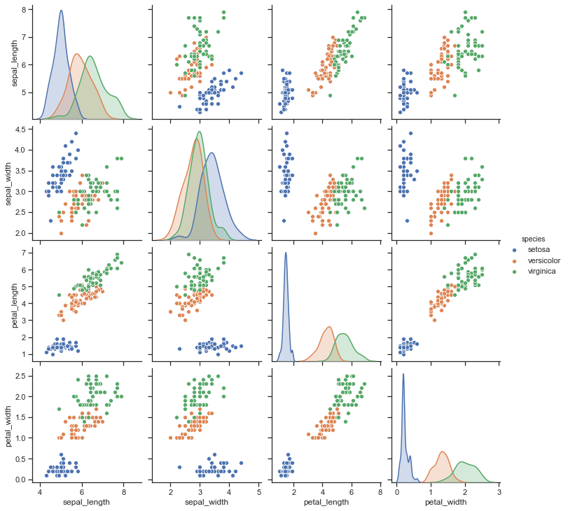

```python
import seaborn as sns
sns.set(style="ticks", color_codes=True)
iris = sns.load_dataset("iris")
g = sns.pairplot(iris, hue='species')
```

Nah sekarang mari kita komparasikan dengan plotly

```python
import plotly.express as px
iris = px.data.iris()
fig_iris= (px.scatter(iris, x="sepal_width", y="sepal_length", color="species",
           facet_col="species", trendline="ols", title="Iris Dataset")
           .update_layout(title_font_size=24)
           .update_xaxes(showgrid=False)
           .update_traces(line=dict(dash="dot", width=4),
           selector=dict(type="scatter", mode="lines"))
          )

fig_iris.show()
```

[interactive chart not shown]

```python
fig_pairplot = px.scatter_matrix(iris, dimensions=["sepal_width","sepal_length","petal_width","petal_length"], labels='species',
                        color="species", symbol="species")
fig_pairplot.show()
```

[interactive chart not shown]

```python
px.scatter(iris, x="sepal_width", y="sepal_length", color="species", marginal_y="histogram",
          marginal_x="box", trendline="ols")
```

[interactive chart not shown]

```python
import plotly.express as px
iris = px.data.iris()
px.density_contour(iris, x='sepal_width',y='sepal_length', color="species")
```

[interactive chart not shown]

```python
import plotly.graph_objects as go
from plotly.subplots import make_subplots
import pandas as pd

# Make figure with subplots
fig = make_subplots(rows=1, cols=2, specs=[[{"type": "bar"},
                                            {"type": "surface"}]])

# Add bar traces to subplot (1, 1)
fig.add_trace(go.Bar(y=[2, 1, 3]), row=1, col=1)
fig.add_trace(go.Bar(y=[3, 2, 1]), row=1, col=1)
fig.add_trace(go.Bar(y=[2.5, 2.5, 3.5]), row=1, col=1)
fig.add_trace(go.Bar(y=[4, 2, 3]), row=1, col=1)
fig.add_trace(go.Bar(y=[5, 1, 2]), row=1, col=1)

# Add surface trace to subplot (1, 2)
# Read data from a csv
z_data = pd.read_csv("mt_bruno_elevation.csv")
fig.add_surface(z=z_data)

# Hide legend
fig.update_layout(
    showlegend=False,
    title_text="Version 4 Default Theme",
    height=500,
    width=800,
)

fig.show()
```

[interactive chart not shown]